# Can You Predict Life Expectancy At Birth For Different Countries?

## Normalizing the dataframe

Seeing the high value of weight for certain features makes me realize that there is an error in data processing stage. I should normalize the values since different scales are used for different columns in the dataset.

```python
columns = ['life_ladder', 'log_GDP_per_capita',
       'social_support', 'life_expectancy', 'freedom_choices', 'generosity',
       'corruption_perception', 'positive_effect', 'negative_effect',
       'government_confidence', 'democratic_quality', 'delivery_quality',
       'ladder_standard_deviation', 'mean_of_ladder', 'gini_WB', 'gini_avg',
       'gini_gallup_5yr']

for column in columns:
    df_normalized[column] = (df_normalized[column] - df_normalized[column].min()) / (df_normalized[column].max() - df_normalized[column].min())
```

```
Model Summary for  life_ladder

Weight =   0.8303941613266514 [ weight of feature: life_ladder  ]
Alpha =  0.19203365876284234 [ intercept ]

Model Performance

RMSE =   0.17
 R^2 =   0.55
---------------------------------------------------------------------------

Model Summary for  log_GDP_per_capita

Weight =   0.8242093320851095 [ weight of feature: log_GDP_per_capita  ]
Alpha =  0.17066931070519437 [ intercept ]

Model Performance

RMSE =   0.14
 R^2 =   0.69
---------------------------------------------------------------------------

Model Summary for  social_support

Weight =   0.6433994738807811 [ weight of feature: social_support  ]
Alpha =  0.1724267515221693 [ intercept ]

Model Performance

RMSE =   0.21
 R^2 =   0.34
---------------------------------------------------------------------------

Model Summary for  freedom_choices

Weight =   0.33232457108967384 [ weight of feature: freedom_choices  ]
Alpha =  0.4195534198874547 [ intercept ]

Model Performance

```

[output cut: 65 more lines]

```

RMSE =   0.21
 R^2 =   0.32
---------------------------------------------------------------------------

Model Summary for  delivery_quality

Weight =   0.6564194014514876 [ weight of feature: delivery_quality  ]
Alpha =  0.3273963438330487 [ intercept ]

Model Performance

RMSE =   0.18
 R^2 =   0.48
---------------------------------------------------------------------------
```

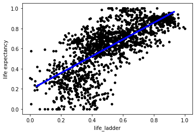

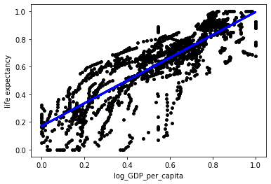

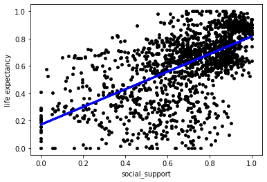

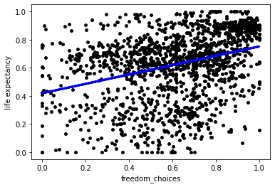

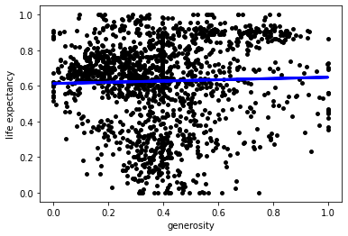

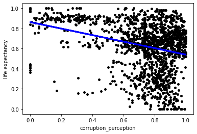

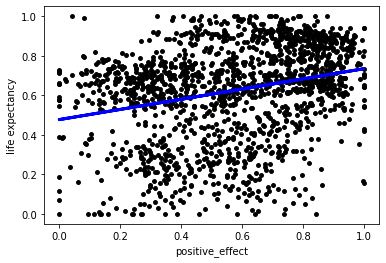

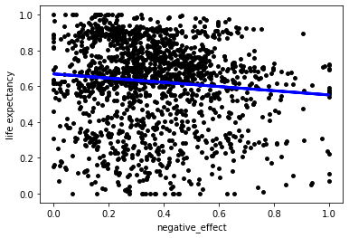

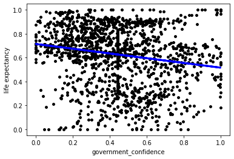

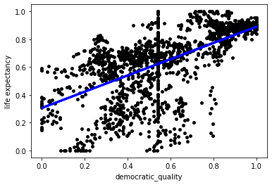

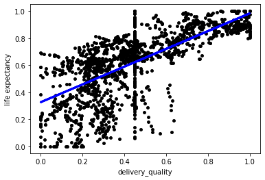

```python
column_names = ['life_ladder', 'log_GDP_per_capita',
       'social_support', 'freedom_choices', 'generosity',
       'corruption_perception', 'positive_effect', 'negative_effect',
       'government_confidence', 'democratic_quality', 'delivery_quality']

for column in column_names:
    X = df_normalized[column].to_frame()
    y = df_normalized['life_expectancy']

    #Train test split
    X_train, X_test, y_train, y_test = train_test_split(X, y, test_size = 0.3, random_state=123)

    #Training the model
    ols_model = LinearRegression()
    ols_model.fit(X_train,y_train)
    prediction = ols_model.predict(X_test)
    print('\nModel Summary for ',column,'\n\nWeight =  ', ols_model.coef_[0], '[ weight of feature:',column, ' ]')
    print('Alpha = ', ols_model.intercept_, '[ intercept ]')
    print('\nModel Performance\n\nRMSE =   %.2f'
      % np.sqrt(mean_squared_error(y_test, prediction)))
    print(' R^2 =   %.2f'
      % r2_score(y_test, prediction))
    print("---------------------------------------------------------------------------")

    #visualize
    plt.figure()
    plt.scatter(X, y,  color='black',s=15)
    plt.plot(X_test, prediction, color='blue', linewidth=3)
    plt.xlabel(column)
    plt.ylabel('life expectancy')
```

### Linear Regression Model Analysis

While observing the results, it was interesting to learn about a negative R2. On reading more about it, I learned that a negative R2 can exist and its refers to when a given model fits worse than a horizontal line and when my chosen model does not follow the trend of the data.

# Decision Tree Regressor

Now that I've used linear regression to train my model. I'm also interested in examining how a decision tree regressor would perform on the same dataset. So, the next section consists of decision tree regressor model training and evaluation.

##### Recreating the training and test sets

It is worth noting that I'm using the df_normalized dataset.

```python
y = df_normalized['life_expectancy']
X = df_normalized.drop(columns = ['life_expectancy', 'country', 'life_expectancy_label'])
```

```python
X_train, X_test, y_train, y_test = train_test_split(X, y, test_size = 0.3, random_state = 123)
```

##### Setting a parameter grid

```python
max_depth = [4,8]
min_samples_leaf = [25,50]

param_grid = {'max_depth': max_depth, 'min_samples_leaf': min_samples_leaf}
```

```python
# Running a grid search by first initializing the decision tree regressor model.

dt_regressor = DecisionTreeRegressor()

dt_grid = GridSearchCV(dt_regressor, param_grid, cv = 3)

dt_grid_search = dt_grid.fit(X_train, y_train)
```

```python
rmse_DT = dt_grid_search.best_score_
print("RMSE for the best model is: ", rmse_DT)
```

```
RMSE for the best model is:  0.7883939845225294
```

```python
# Finding the best parameters
dt_best_params = dt_grid_search.best_params_
dt_best_params
```

```
{'max_depth': 8, 'min_samples_leaf': 25}
```

```python
# Using these parameters to fit and re-evaluate the model
dt_model = DecisionTreeRegressor(max_depth = 8, min_samples_leaf = 25)
dt_model.fit(X_train, y_train)

prediction = dt_model.predict(X_test)
dt_rmse = mean_squared_error(y_test, prediction, squared = False)
dt_r2 = r2_score(y_test,prediction)
```

```python
print("RMSE for new DT Regressor model: ", dt_rmse)
print("R2 score: ", dt_r2)
```

```
RMSE for new DT Regressor model:  0.11744432432043246
R2 score:  0.7884196422013722
```

### Analysis for Decision Tree Regressor Model

Using grid search enabled us to further improve the model performance by providing the best hyperparameters. Using these hyperparameters, we were able to optimize the model.

# Ensemble Modeling

I'm interested in learning whether there we can achieve better model performance compared to what we could achieve with Decision Tree Regressor. Hence, I'm trying Gradient Boosting and Random Forest techniques on the normalized dataset.

### Gradient Boosting Regressor

##### Creating and fitting the model

```python
gbdt_model = GradientBoostingRegressor(max_depth = 3, n_estimators = 100)
gbdt_model.fit(X_train, y_train)
y_gbdt = gbdt_model.predict(X_test)
```

##### Calculating RMSE and R2 scores

```python
gbdt_rmse = mean_squared_error(y_test, y_gbdt, squared = False)

gbdt_r2 = r2_score(y_test, y_gbdt)
```

```python
print("RMSE for GBDT model: ", gbdt_rmse)
print("R2: ", gbdt_r2)
```

```
RMSE for GBDT model:  0.07888231263680062
R2:  0.904551183229596
```

### Analysis for Gradient Boosting Regressor Model

As observed above, we can see that the RMSE is incredibly low for Gradient Boosting regressor model. R2 is pretty impressive too.

Another observation was that the value of n_estimators above 100 has a very little influence on the RMSE and R2 scores of the model. For example:  
n_estimators = 100, RMSE = 0.07918  
n_estimators = 200, RMSE = 0.07244  
n_estimators = 300, RMSE = 0.07089

So it is worth noting that if I had a higher number of datapoints, then I would go with a lower n_estimators values (depending on where the RMSE values reach a plateau) as it will be less computationally expensive.

### Random Forest Model

##### Initializing the model

In this code block, I will also use different values for n_estimators to see which n_estimator value is best for the model in terms of both model performance and computational use.

```python
n_estimator = [100, 200, 300, 400, 500]

for n in n_estimator:
    rf_model = RandomForestRegressor(max_depth = 32, n_estimators = n) #testing the ideal value for n
    rf_model.fit(X_train, y_train)
    rf_y_pred = rf_model.predict(X_test)
    rf_rmse = mean_squared_error(y_test, rf_y_pred, squared = False)
    rf_r2 = r2_score(y_test, rf_y_pred)

    print("RMSE for n_estimators ", n, " = ", rf_rmse)
    print("R2_score for n_estimators ", n, " = ", rf_r2)
    print("--------------------------------------------------------")
```

```
RMSE for n_estimators  100  =  0.07476010843395128
R2_score for n_estimators  100  =  0.9142663872155729
--------------------------------------------------------
RMSE for n_estimators  200  =  0.0734342064728498
R2_score for n_estimators  200  =  0.9172804634748956
--------------------------------------------------------
RMSE for n_estimators  300  =  0.0738136486404338
R2_score for n_estimators  300  =  0.9164234140855263
--------------------------------------------------------
RMSE for n_estimators  400  =  0.0748789900908593
R2_score for n_estimators  400  =  0.9139935075258963
--------------------------------------------------------
RMSE for n_estimators  500  =  0.07323691072406122
R2_score for n_estimators  500  =  0.9177243516821939
--------------------------------------------------------
```

```python
# I chose n_estimators = 200
rf_model = RandomForestRegressor(max_depth = 32, n_estimators = 200) #testing th
rf_model.fit(X_train, y_train)
rf_y_pred = rf_model.predict(X_test)
rf_rmse = mean_squared_error(y_test, rf_y_pred, squared = False)
rf_r2 = r2_score(y_test, rf_y_pred)

print("RMSE for Random Forest Model = ", rf_rmse)
print("R2_score = ", rf_r2)
```

```
RMSE for Random Forest Model =  0.07344730733747297
R2_score =  0.9172509460559959
```

# Overall Analysis

##### Visualizing the model performance based on different modeling techniques used

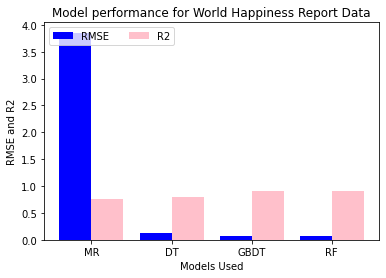

```python
RMSE_values = [mr_rmse, dt_rmse, gbdt_rmse, rf_rmse]
R2_values = [mr_r2, dt_r2, gbdt_r2, rf_r2]
labels = ['MR', 'DT', 'GBDT', 'RF']

rg = np.arange(4)
width = 0.4
plt.bar(rg, RMSE_values, width, label = "RMSE", color = 'blue')
plt.bar(rg+width, R2_values, width, label = "R2", color = 'pink')

# Adding labels to plot
plt.xticks(rg + width/2, labels)
plt.xlabel("Models Used")
plt.ylabel("RMSE and R2")

plt.title("Model performance for World Happiness Report Data")
plt.legend(loc = 'upper left', ncol =2)
plt.show()
```

From the above plot, we see that Gradient Boosting Decision Trees and Random Forest are the best model candidates for this dataset. It is worth noting that these models have a high computational need and it depends on the specific business need to implement these ensemble methods.

Also, multiple regression does have a high R2 but does not perform well in terms of reducing model estimation error. At one stage of model training, I used linear regression to mitigate this challenge. Here, one should be careful of simply implementing the linear regression model because it might fail to capture relationship between different features that contribute towards an accurate prediction of life expectancy.

Another observation to keep in mind is the use of n_estimators and the business model need. Using a high number of n_estimators (to a certain threshold) can provide models with low error. However, it is worth considering the marginal benefit gained from lower error versus the marginal cost of computation based on the dataset being trained and the business issue at stake.